# Stout Case Study 2: Data Manipulation and Visualization

Theresa Pham

12/24/2022

*Read and look at data*

```r
orders <- read.csv("casestudy.csv")
glimpse(orders)
```

```
## Rows: 685,927
## Columns: 4
## $ X              <int> 0, 1, 2, 3, 4, 5, 6, 7, 8, 9, 10, 11, 12, 13, 14, 15, 1~
## $ customer_email <chr> " nhknapwsbx@gmail.com", "joiuzbvcpn@gmail.com", "ukkjc~
## $ net_revenue    <dbl> 249.92, 87.61, 168.38, 62.40, 43.08, 39.44, 171.46, 111~
## $ year           <int> 2015, 2015, 2015, 2015, 2015, 2015, 2015, 2015, 2015, 2~
```

```r
head(orders)
```

```
##   X        customer_email net_revenue year
## 1 0  nhknapwsbx@gmail.com      249.92 2015
## 2 1  joiuzbvcpn@gmail.com       87.61 2015
## 3 2  ukkjctepxt@gmail.com      168.38 2015
## 4 3  gykatilzrt@gmail.com       62.40 2015
## 5 4  mmsgsrtxah@gmail.com       43.08 2015
## 6 5  mobvusnzfr@gmail.com       39.44 2015
```

## Data Manipulation

We will extract and calculate information for each year, so we will find how many years there are in the data set.

```r
table(orders$year)
```

```
##
##   2015   2016   2017
## 231294 204646 249987
```

For each prompt, we should obtain results for each year applicable.

**Total revenue for the current year**

```r
Total_Rev <- orders %>%
  group_by(year) %>%
  summarise(total_rev = sum(net_revenue))
Total_Rev
```

```
## # A tibble: 3 x 2
##    year total_rev
##   <int>     <dbl>
## 1  2015 29036749.
## 2  2016 25730944.
## 3  2017 31417495.
```

**New Customer Revenue** (new customers not present in previous year only)

```r
custs2015 <- orders %>%
  filter(year == 2015)
custs2016 <- orders %>%
  filter(year == 2016)
custs2017 <- orders %>%
  filter(year == 2017)

# all customers in 2015 are "new" for 2015
new2015 <- custs2015

# new customers in 2016
new2016 <- anti_join(custs2016, custs2015, by="customer_email")

# new customers in 2017
new2017 <- anti_join(custs2017, custs2016, by="customer_email")

# create new new data frame with new customers only
new_orders <- bind_rows(new2015, new2016, new2017)

New_Cust_Rev <- new_orders %>%
  group_by(year) %>%
  summarise(new_cust_rev = sum(net_revenue))
New_Cust_Rev
```

```
## # A tibble: 3 x 2
##    year new_cust_rev
##   <int>        <dbl>
## 1  2015    29036749.
## 2  2016    18245491.
## 3  2017    28776235.
```

Note that we do not have data on years before 2015, thus we cannot accurately determine whether customers are new in 2015.

**Existing Customer Growth** (Revenue of existing customers for current year minus Revenue of existing customers from the previous year)

```r
# existing customers = all current customers - new customers

existing_rev <- Total_Rev %>%
  left_join(New_Cust_Rev, by="year") %>%
  mutate(existing_rev = total_rev - new_cust_rev) %>%
  mutate(prev_existing_rev = lag(existing_rev))
existing_rev
```

```
## # A tibble: 3 x 5
##    year total_rev new_cust_rev existing_rev prev_existing_rev
##   <int>     <dbl>        <dbl>        <dbl>             <dbl>
## 1  2015 29036749.    29036749.           0                NA
## 2  2016 25730944.    18245491.     7485453.                0
## 3  2017 31417495.    28776235.     2641260.          7485453.
```

```r
Existing_Cust_Growth <- existing_rev %>%
  mutate(existing_cust_growth = existing_rev - prev_existing_rev) %>%
  select(year, existing_cust_growth)
Existing_Cust_Growth
```

```
## # A tibble: 3 x 2
##    year existing_cust_growth
##   <int>                <dbl>
## 1  2015                  NA
## 2  2016             7485453.
## 3  2017            -4844193.
```

Note that revenues may be off again due to missing data from year before 2015. We assumed all 2015 customers to be “new”, thus there is no existing customer revenue for that year.

**Revenue lost from attrition** (revenue lost from lost customers)

```r
# We are assuming no customers lost in 2015

# lost customers in 2016
lost2016 <- anti_join(custs2015, custs2016, by="customer_email")

# lost customers in 2017
lost2017 <- anti_join(custs2016, custs2017, by="customer_email")

# create new new data frame with lost customers only
lost_custs <- bind_rows(lost2016, lost2017)

Attrition_Rev_Lost <- lost_custs %>%
  group_by(year) %>%
  summarise(attrition_rev_lost = sum(net_revenue)) %>%
  rename(prev_year = year) %>%
  mutate(year = prev_year + 1) %>%
  add_row(prev_year = 2014, year = 2015, attrition_rev_lost = 0) %>%
  arrange(prev_year)

col_order <- c("prev_year", "year", "attrition_rev_lost")
Attrition_Rev_Lost <- Attrition_Rev_Lost[, col_order]
Attrition_Rev_Lost
```

```
## # A tibble: 3 x 3
##   prev_year  year attrition_rev_lost
##       <dbl> <dbl>              <dbl>
## 1      2014  2015                 0
## 2      2015  2016          21571632.
## 3      2016  2017          23110295.
```

Since we do not have data from 2014, we assume no customers were lost in 2015.

**Existing Customer Revenue Current Year**

```r
Current_Existing_Rev <- existing_rev %>%
  select(year, existing_rev)
Current_Existing_Rev
```

```
## # A tibble: 3 x 2
##    year existing_rev
##   <int>        <dbl>
## 1  2015           0
## 2  2016     7485453.
## 3  2017     2641260.
```

**Existing Customer Revenue Prior Year**

```r
Prev_Existing_Rev <- existing_rev %>%
  select(year, prev_existing_rev)
Prev_Existing_Rev
```

```
## # A tibble: 3 x 2
##    year prev_existing_rev
##   <int>             <dbl>
## 1  2015               NA
## 2  2016                0
## 3  2017          7485453.
```

**Total Customers Current Year**

```r
Total_Custs <- orders %>%
  group_by(year) %>%
  summarise(total_custs = n())
Total_Custs
```

```
## # A tibble: 3 x 2
##    year total_custs
##   <int>       <int>
## 1  2015      231294
## 2  2016      204646
## 3  2017      249987
```

**Total Customers Previous Year**

```r
Prev_Total_Custs <- Total_Custs %>%
  mutate(prev_total_custs = lag(total_custs)) %>%
  select(year, prev_total_custs)
Prev_Total_Custs
```

```
## # A tibble: 3 x 2
##    year prev_total_custs
##   <int>            <int>
## 1  2015               NA
## 2  2016           231294
## 3  2017           204646
```

**New Customers**

```r
New_Custs <- new_orders %>%
  group_by(year) %>%
  summarise(new_custs = n())
New_Custs
```

```
## # A tibble: 3 x 2
##    year new_custs
##   <int>     <int>
## 1  2015    231294
## 2  2016    145062
## 3  2017    229028
```

**Lost Customers**

```r
Lost_Custs <- lost_custs %>%
  mutate(current_year = year + 1) %>%
  group_by(current_year) %>%
  summarise(lost_custs = n()) %>%
  rename(year = current_year) %>%
  add_row(year = 2015, lost_custs = 0) %>%
  arrange(year)

Lost_Custs
```

```
## # A tibble: 3 x 2
##    year lost_custs
##   <dbl>      <dbl>
## 1  2015          0
## 2  2016     171710
## 3  2017     183687
```

## Visualizations and Observations

**Grouped Bar Chart Comparing Lost, New, and Existing Customer Count**

```r
# Data frame with existing, new, and lost customer count
Existing_Custs <- Total_Custs %>%
  full_join(New_Custs) %>%
  mutate(existing_custs = total_custs - new_custs)
#Existing_Custs

custs_df <- Existing_Custs %>% full_join(Lost_Custs, by='year')
custs_df
```

```
## # A tibble: 3 x 5
##    year total_custs new_custs existing_custs lost_custs
##   <dbl>       <int>     <int>          <int>      <dbl>
## 1  2015      231294    231294              0          0
## 2  2016      204646    145062          59584     171710
## 3  2017      249987    229028          20959     183687
```

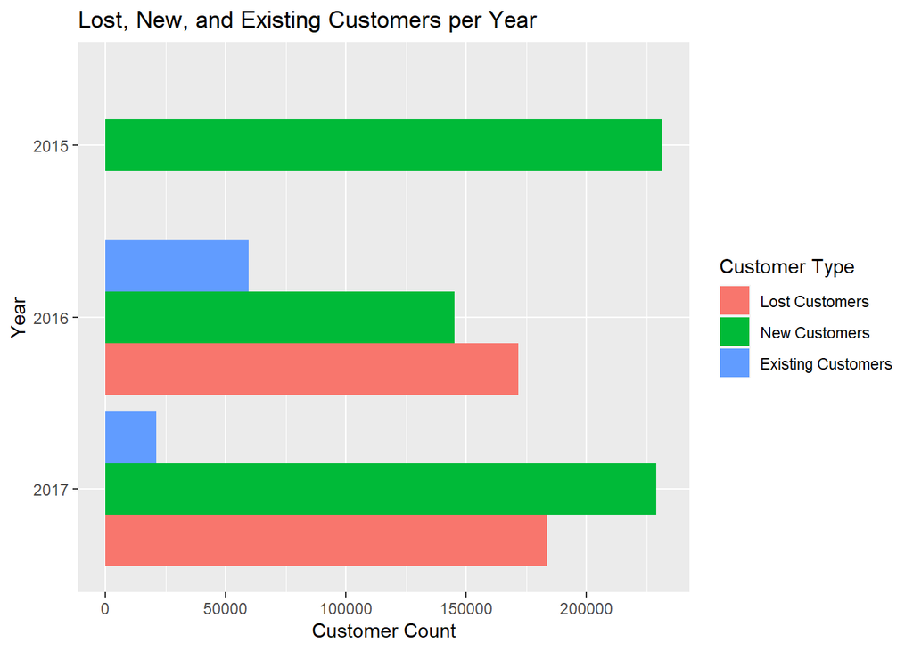

```r
custs_df_long <- custs_df %>%
  pivot_longer(cols = 3:5,
               names_to = "cust_type",
               values_to = "cust_count")

custs_df_long$cust_type <- factor(custs_df_long$cust_type, levels = c('lost_custs', 'new_custs', 'existing_custs'))

custs_df_long$year <- factor(custs_df_long$year, levels = c('2017', '2016', '2015'))

custs_df_long %>%
  ggplot(aes(x=year, y=cust_count, fill=cust_type)) +
  geom_bar(stat="identity", position=position_dodge()) +
  coord_flip() +
  ggtitle("Lost, New, and Existing Customers per Year") +
  labs(x="Year", y="Customer Count", fill="Customer Type") +
  scale_fill_discrete(labels=c("Lost Customers", "New Customers", "Existing Customers"))
```

Observations: Although we only have data on three years and assume that all customers in 2015 are “new”, we can observe that the number of existing, or returning, customers is far below the number of lost customers, thus customer retention is not well. We can also see that the number of lost and and new customers are both increasing in the latter two years.

**Line Graph of Total Revenue Over Time**

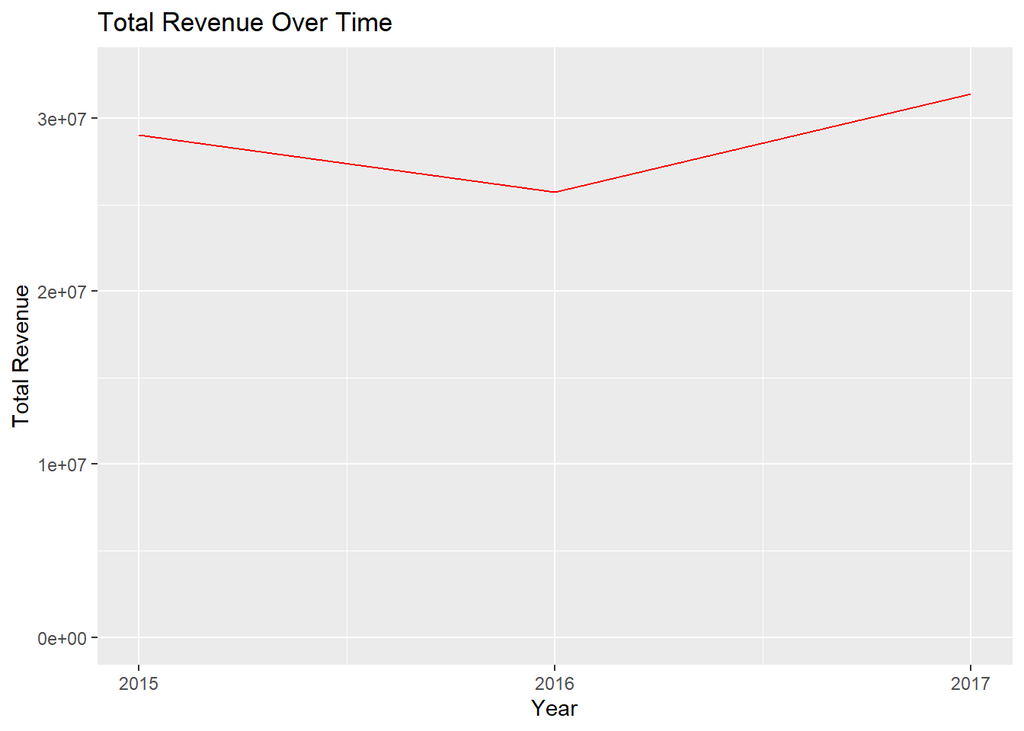

```r
Total_Rev %>%
  ggplot((aes(x=year, y=total_rev))) +
  geom_line(color="red") +
  ggtitle("Total Revenue Over Time") +
  labs(x="Year", y="Total Revenue") +
  scale_x_continuous(breaks = seq(2015, 2017, 1)) +
  ylim(0, 32500000)
```

Observations: The total revenue does not fluctuate drastically within the three recorded years, but we can notice a dip in revenue in 2016.

**Stacked Bar Chart of New and Existing Customer Revenue**

```r
# Data frame with total, existing, and new revenue
rev_list <- list(Total_Rev, Current_Existing_Rev, New_Cust_Rev)

rev_df <- rev_list %>% reduce(full_join, by = 'year')
rev_df
```

```
## # A tibble: 3 x 4
##    year total_rev existing_rev new_cust_rev
##   <int>     <dbl>        <dbl>        <dbl>
## 1  2015 29036749.           0     29036749.
## 2  2016 25730944.     7485453.    18245491.
## 3  2017 31417495.     2641260.    28776235.
```

```r
rev_df_long <- rev_df %>%
  pivot_longer(cols = 3:4,
               names_to = "rev_type",
               values_to = "rev_amount")
rev_df_long
```

```
## # A tibble: 6 x 4
##    year total_rev rev_type     rev_amount
##   <int>     <dbl> <chr>             <dbl>
## 1  2015 29036749. existing_rev         0
## 2  2015 29036749. new_cust_rev  29036749.
## 3  2016 25730944. existing_rev   7485453.
## 4  2016 25730944. new_cust_rev  18245491.
## 5  2017 31417495. existing_rev   2641260.
## 6  2017 31417495. new_cust_rev  28776235.
```

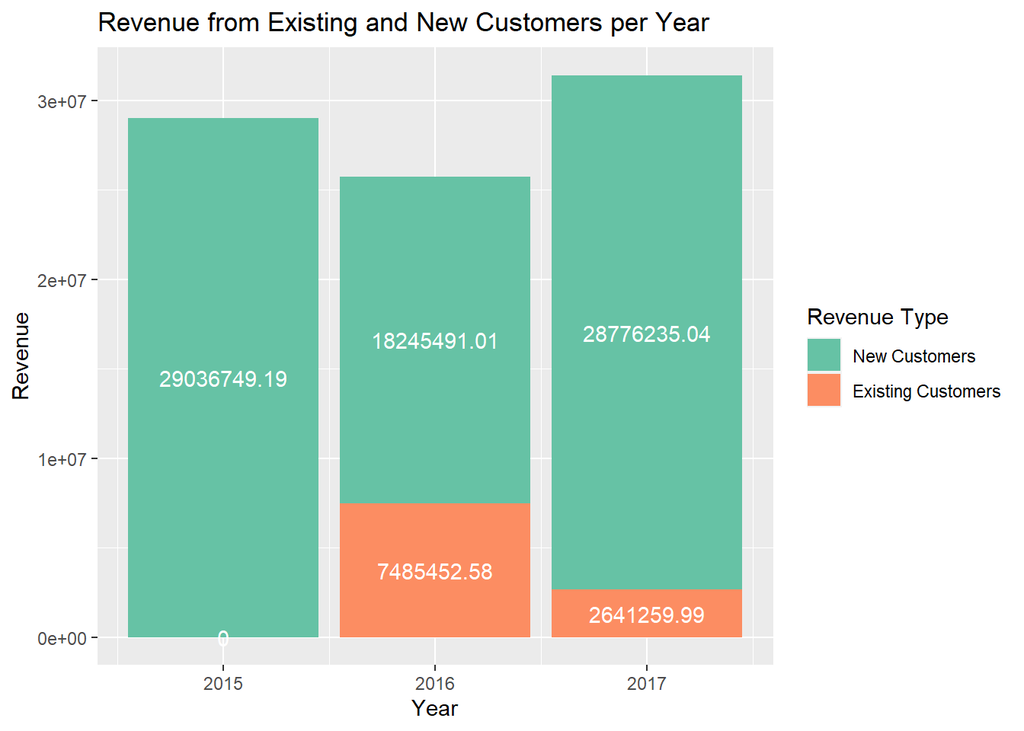

```r
rev_df_long$rev_type <- factor(rev_df_long$rev_type, levels = c('new_cust_rev', 'existing_rev'))

rev_df_long %>%
  ggplot(aes(x=year, y=rev_amount, fill=rev_type)) +
  geom_bar(stat="identity", position="stack") +
  ggtitle("Revenue from Existing and New Customers per Year") +
  labs(x="Year", y="Revenue", fill="Revenue Type") +
  scale_fill_brewer(labels=c("New Customers", "Existing Customers"), palette = "Set2") +
  geom_text(aes(x=year, y=rev_amount, label=rev_amount, group=rev_type),
            position=position_stack(vjust = .5), colour="white")
```

Observations: The majority of total revenue is made up of new customers every year, and 2017 has the highest total revenue out of all three years.